# CFSS Homework 02

Cory J. Cascalheira

November 28, 2018

# Exploring Gun Deaths in America

Let’s explore gun deaths in America between the years 2012 to 2014. These data, originally compiled by FiveThirtyEight, are taken from [MACS 30500](https://cfss.uchicago.edu/index.html), Computing for the Social Sciences, a course taught by [Ben Soltoff](http://www.bensoltoff.com/) at the University of Chicago.

TO begin, we must load dependencies and import data to construct the workspace.

```r
library(tidyverse) # utility & visualization
library(knitr) # tables
library(kableExtra) # awesome tables
library(RColorBrewer) # custome colors

# Import data
load(file = "data/gun_deaths.rda")
```

Let’s also set the default theme for all of our plots.

```r
theme_set(theme_classic())
```

## Understand the Variables

If the data were untidy, now would be the time to clean them. That is, we would want to ensure that each cell has exactly one value, each column one variable, and each row one observation. Thanfully, the instructor has cleaned the data ahead of time.

```r
glimpse(gun_deaths)
```

```
## Observations: 100,798
## Variables: 10
## $ id        <int> 1, 2, 3, 4, 5, 6, 7, 8, 9, 10, 11, 12, 13, 14, 15, 1...
## $ year      <int> 2012, 2012, 2012, 2012, 2012, 2012, 2012, 2012, 2012...
## $ month     <dbl> 1, 1, 1, 2, 2, 2, 2, 3, 2, 2, 2, 1, 3, 3, 3, 3, 3, 3...
## $ intent    <chr> "Suicide", "Suicide", "Suicide", "Suicide", "Suicide...
## $ police    <int> 0, 0, 0, 0, 0, 0, 0, 0, 0, 0, 0, 0, 0, 0, 0, 0, 0, 0...
## $ sex       <chr> "M", "F", "M", "M", "M", "M", "M", "M", "M", "M", "M...
## $ age       <int> 34, 21, 60, 64, 31, 17, 48, 41, 50, NA, 30, 21, 43, ...
## $ race      <chr> "Asian/Pacific Islander", "White", "White", "White",...
## $ place     <chr> "Home", "Street", "Other specified", "Home", "Other ...
## $ education <fct> BA+, Some college, BA+, BA+, HS/GED, Less than HS, H...
```

Aside from one `double` and `factor`, the data are comprised of `integer`s and `character`s.

What are the levels of the factor?

```r
levels(gun_deaths$education)
```

```
## [1] "Less than HS" "HS/GED"       "Some college" "BA+"
```

Alright, so the `education` variable is at the ordinal level.

## Number of Gun Deaths per Month

Before we tabulate and visualize the data, let’s transform `month` into a factor with named levels.

```r
# Vector of month names
abbr_months <- c("Jan", "Feb", "Mar", "Apr", "May", "Jun", "Jul", "Aug", "Sep", "Oct", "Nov", "Dec")

# Transform month into a named factor
gun_deaths2 <- within(gun_deaths, {
  month <- factor(month, labels = abbr_months)
})
```

Tables exhibit quantitative information more precisely than graphics. Algorithms prefer tabular data.

```r
# Count the rows, which represent deaths
count(gun_deaths2, month) %>%
  # Create the HTML table
  kable(caption = "Total Gun Deaths in the United States (2012-2014) per Month",
        col.names = c("Month", "Total Deaths")) %>%
  # Give the table some CSS love
  kable_styling(bootstrap_options = c("striped", "hover"))
```

Total Gun Deaths in the United States (2012-2014) per Month

| Month | Total Deaths |
| --- | --- |
| Jan | 8273 |
| Feb | 7093 |
| Mar | 8289 |
| Apr | 8455 |
| May | 8669 |
| Jun | 8677 |
| Jul | 8989 |
| Aug | 8783 |
| Sep | 8508 |
| Oct | 8406 |
| Nov | 8243 |
| Dec | 8413 |

As humans, we tend to grasp patterns in visualizations better. The only number that jumps out to us after a quick glance at the above table is the leading digital, eight. Our minds blur the remaining digits as nonsensical. This is why $5.99 feels like five dollars and not six.

What does a bar chart[^2] tell us?

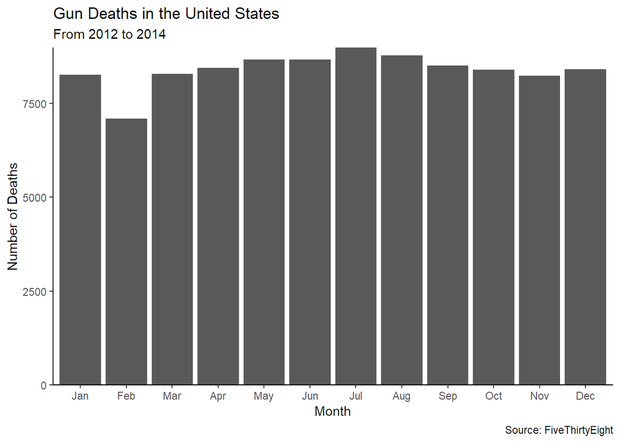

```r
ggplot(gun_deaths2, aes(x = month)) +
  geom_bar() +
  # Describe the graph
  labs(title = "Gun Deaths in the United States",
       subtitle = "From 2012 to 2014",
       caption = "Source: FiveThirtyEight",
       x = "Month",
       y = "Number of Deaths") +
  # Force origin to start at 0
  scale_y_continuous(expand = c(0, 0))
```

It is tempting to think that the fewest deaths occurred in February due to Valentine’s Day. Romantic! However, perhaps this is due to the shortness of the month–fewer days to commit homicide.

This pattern holds even when we break down the months by year.

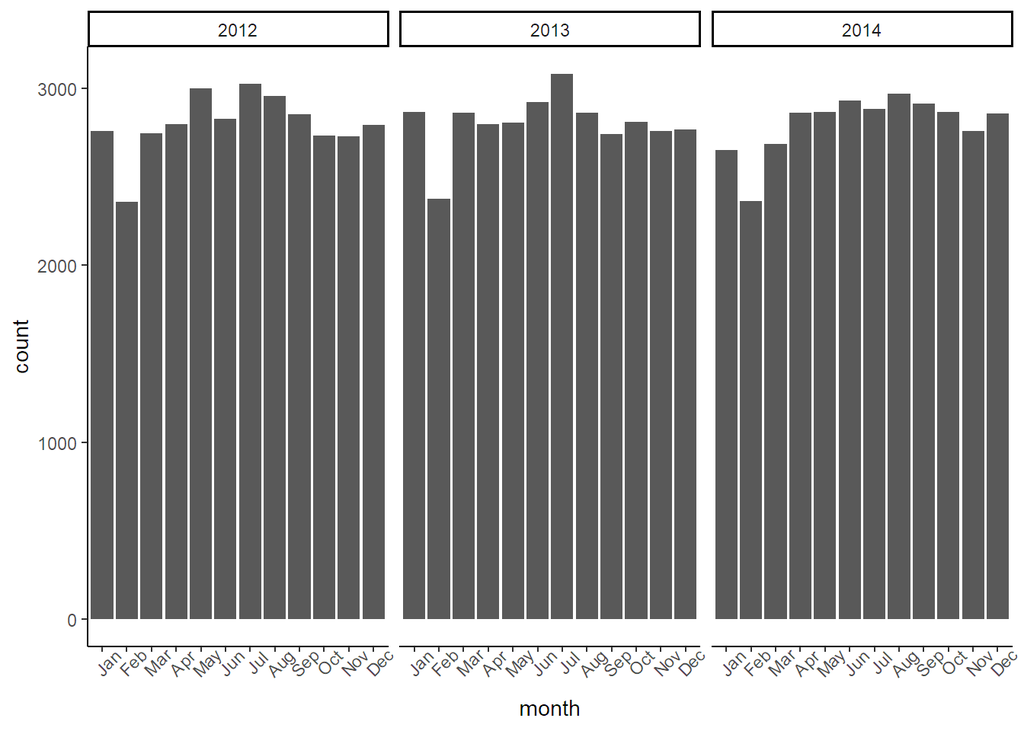

```r
ggplot(gun_deaths2, aes(x = month)) +
  geom_bar() +
  facet_wrap(~ year) +
  # Rotate axis labels
  theme(axis.text.x = element_text(angle = 45))
```

## Number of Gun Deaths by Intent

Earlier, I hypothesized that there are fewer deaths in the month of February due to fewer days to commit homicide. But maybe people kill themselves in February due to loneliness?

```r
unique(gun_deaths2$intent)
```

```
## [1] "Suicide"      "Undetermined" "Accidental"   "Homicide"
## [5] NA
```

Intent is an important variable to consider. First, how many gun deaths are associated with specific intents?

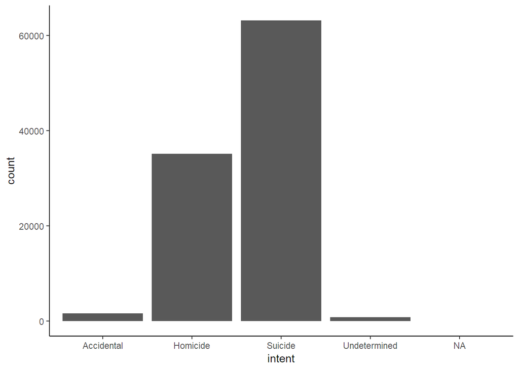

```r
ggplot(gun_deaths2, aes(x = intent)) +
  geom_bar()
```

Unfortunately, suicide is the leading cause of gun death in the United States, at least between the years 2012 and 2014.

Now that we know how many deaths correspond to each type of intent, we can reorder the bar graph. Let’s remove the `NA` values, too. Reordering a bar graph requires a transformation of `intent` into a factor and specification of the levels.

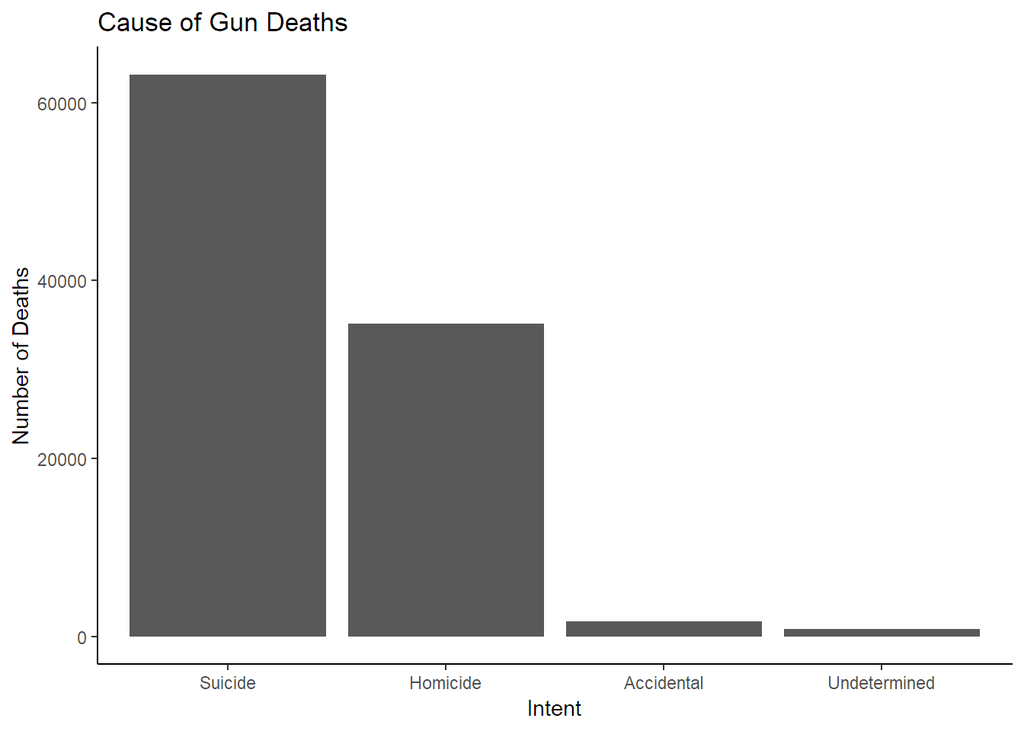

```r
# Intent as a factor
gun_deaths3 <- within(gun_deaths2, {
  intent <- factor(intent, levels = c("Suicide", "Homicide", "Accidental", "Undetermined", NA))
})

# Remove NA
gun_deaths3 %>%
  filter(!is.na(intent)) %>%
  # Plot reordered bar graph
  ggplot(aes(x = intent)) +
    geom_bar() +
    labs(title = "Cause of Gun Deaths",
         x = "Intent",
         y = "Number of Deaths")
```

So, are there more suicides in February?

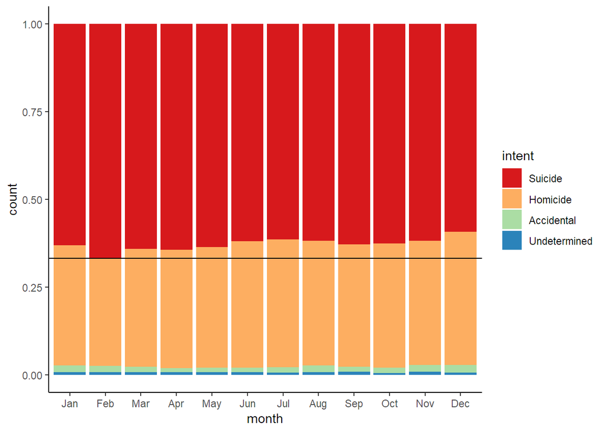

```r
gun_deaths3 %>%
  filter(!is.na(intent)) %>%
  ggplot(aes(x = month, fill = intent)) +
    geom_bar(position = "fill") +
    # Draw horizontal line to compare suicide across months
    geom_hline(yintercept = 0.333) +
    scale_fill_brewer(palette = "Spectral")
```

Yes, they are.

## Age of Victims by Sex

How old are the victims when they die by gun violence?

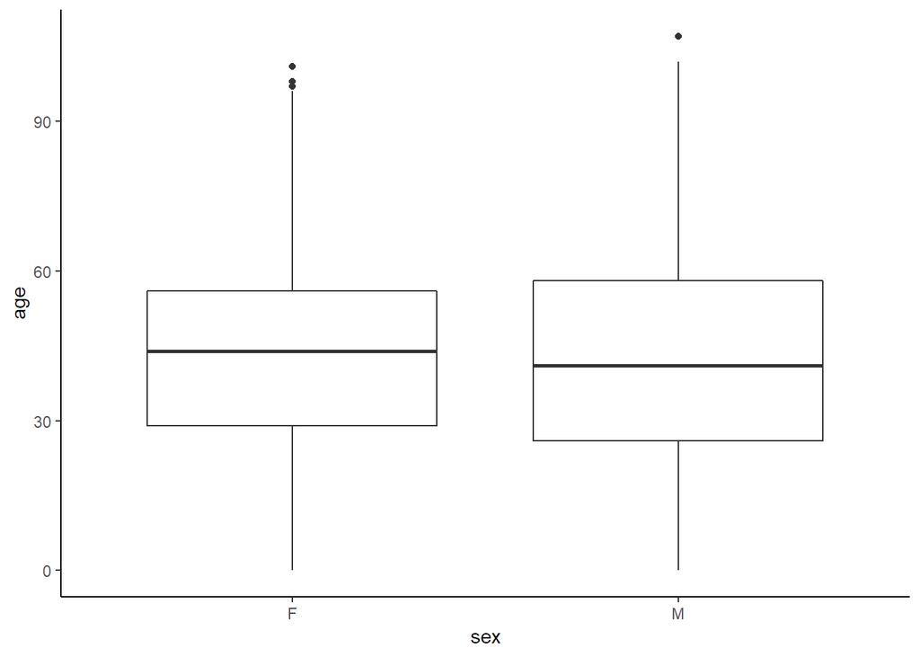

```r
ggplot(gun_deaths3, aes(x = sex, y = age)) +
  geom_boxplot()
```

```r
(gun_death_desc <- gun_deaths3 %>%
  group_by(sex) %>%
  summarize(
    percentile_75 = quantile(age, p = .75,  na.rm = TRUE),
    median_age = median(age, na.rm = TRUE),
    percentile_25 = quantile(age, p = 0.25, na.rm = TRUE),
    mean_age = mean(age, na.rm = TRUE)
  ))
```

```
## # A tibble: 2 x 5
##   sex   percentile_75 median_age percentile_25 mean_age
##   <chr>         <dbl>      <dbl>         <dbl>    <dbl>
## 1 F                56         44            29     43.7
## 2 M                58         41            26     43.9
```

Most victims die in the middle of life, men between the ages of 26 and 58. Women die most often around the age of 44.

## Gun Death of White Males in 2012

How many white males with at least a high school education were killed by guns in 2012?

We can answer this question by filtering with logical statements. Note that at least a high school education is the same as not less than a high school education.

```r
levels(gun_deaths3$education)
```

```
## [1] "Less than HS" "HS/GED"       "Some college" "BA+"
```

```r
gun_deaths3 %>%
  # Filter rows for target demographic in appropriate year
  filter(education != "Less than HS", race == "White", sex == "M", year == 2012) %>%
  count()
```

```
## # A tibble: 1 x 1
##       n
##   <int>
## 1 15199
```

15,199 White men with at least a high school education died by gun violence in 2012.

Delineation of this quantity may reveal other trends.

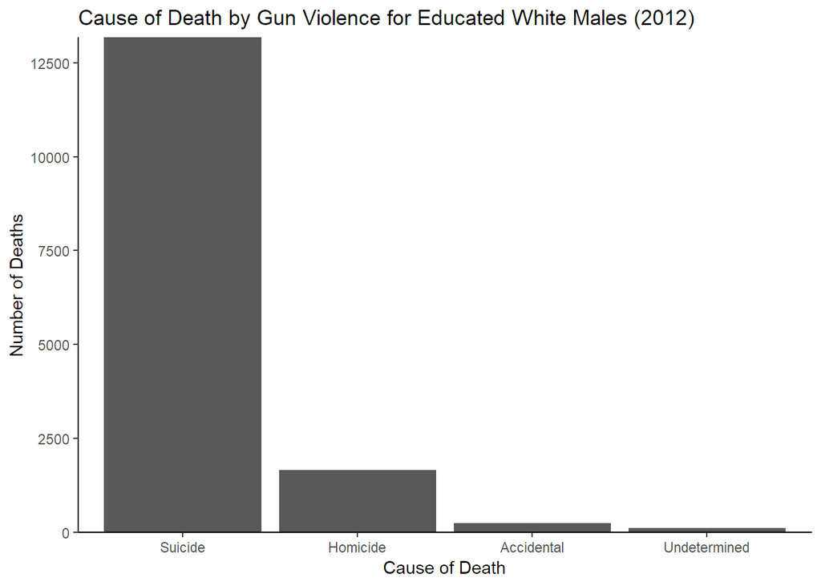

```r
gun_deaths3 %>%
  # Filter rows for target demographic in appropriate year
  filter(education != "Less than HS", race == "White", sex == "M", year == 2012) %>%
  ggplot(aes(x = intent)) +
    geom_bar(position = "dodge") +
    scale_y_continuous(expand = c(0, 0)) +
    labs(title = "Cause of Death by Gun Violence for Educated White Males (2012)",
         x = "Cause of Death",
         y = "Number of Deaths")
```

Suicide is the leading cause of gun-related death for this demographic.

## Gun Deaths by Season

Which season of the year has the most gun deaths?

We can use `cut()` on the original data frame to divide `month` into four equal seasons.

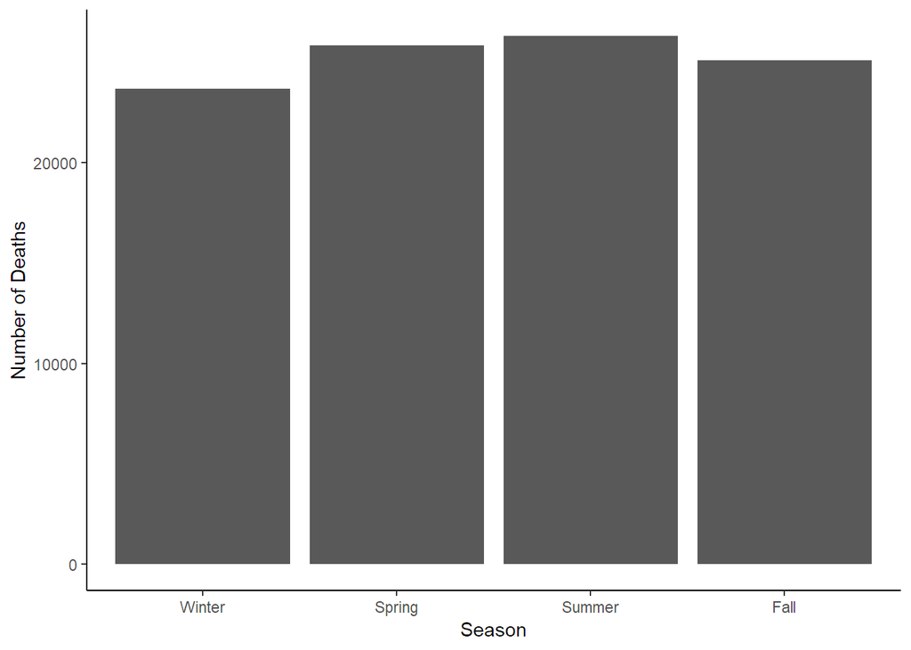

```r
ggplot(gun_deaths, aes(x = cut(month, 4, include.lowest = TRUE,
                               labels = c("Winter", "Spring", "Summer", "Fall")))) +
  geom_bar() +
  labs(x = "Season",
       y = "Number of Deaths")
```

Summer has the highest number of gun-related deaths.

## Death Disparities by Race

Are whites who are killed by guns more likely to die because of suicide or homicide? How does this compare to blacks and hispanics?

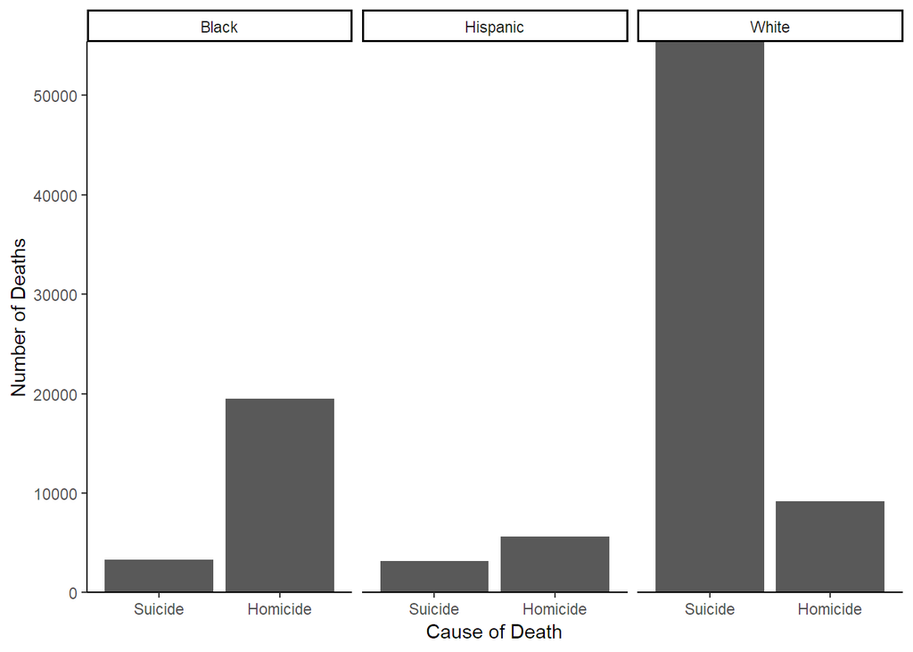

```r
gun_deaths3 %>%
  # Filter for cause fo death
  filter(intent == "Suicide" | intent == "Homicide") %>%
  # Filter only for races in question
  filter(race == "Black" | race == "White" | race == "Hispanic") %>%
  ggplot(aes(x = intent)) +
    geom_bar() +
    facet_wrap(~ race) +
    scale_y_continuous(expand = c(0, 0)) +
    labs(x = "Cause of Death",
         y = "Number of Deaths")
```

Whites are more than five-times as likely to die by suicide than Blacks or Hispanics.

## Police-Involved Gun Deaths

Are police-involved gun deaths significantly different from other gun deaths?

What does the police variable look like?

```r
unique(gun_deaths3$police)
```

```
## [1] 0 1
```

Binary. 0 means no police-involvement. Let’s visualize the interaction between race and police-involvement.

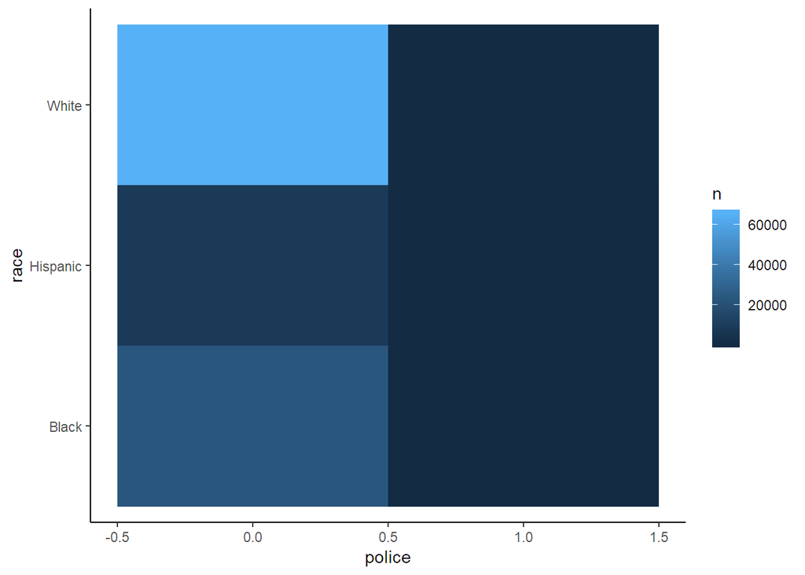

```r
gun_deaths3 %>%
  filter(race == "Black" | race == "White" | race == "Hispanic") %>%
  count(race, police) %>%
  ggplot(aes(x = police, y = race)) +
    geom_tile(aes(fill = n))
```

The tile plot is not very informative. What if we filter for police-involvement and plot the interaction in a bar graph?

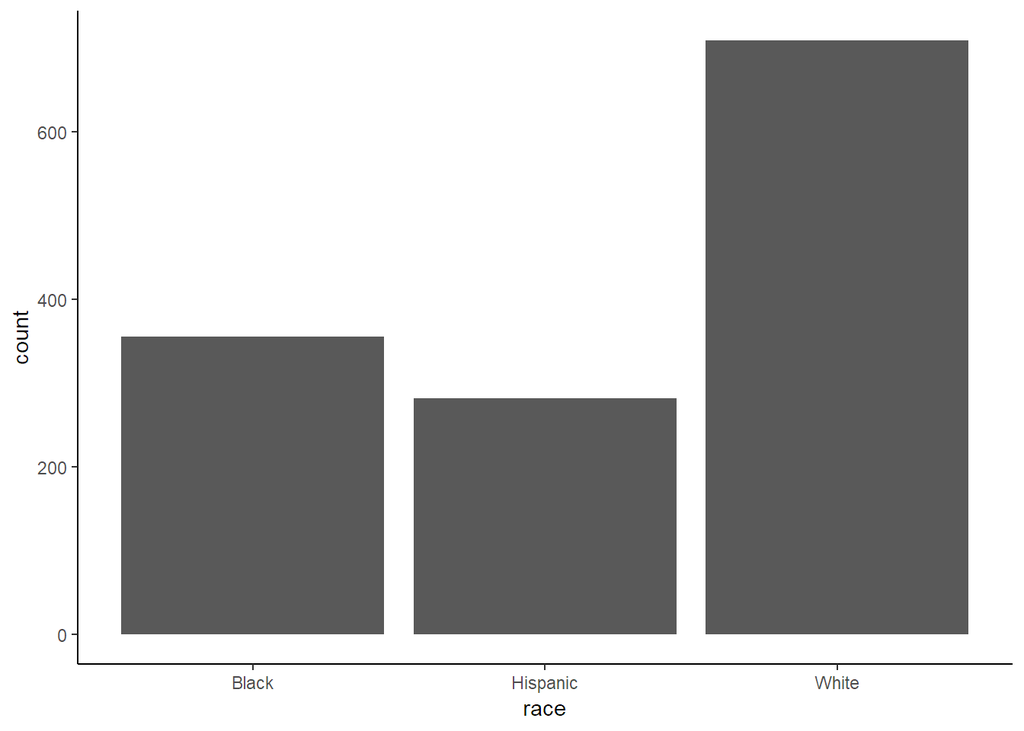

```r
gun_deaths3 %>%
  filter(police == 1) %>%
  filter(race == "Black" | race == "White" | race == "Hispanic") %>%
  ggplot(aes(x = race)) +
    geom_bar()
```

Okay, so police are involved in more White cases than Black or Hispanic. Is there a difference if we focus on homicides?

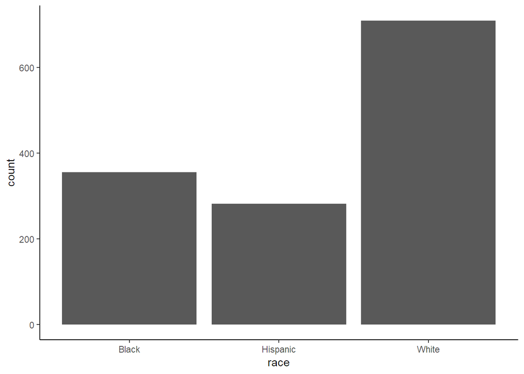

```r
gun_deaths3 %>%
  filter(police == 1 & intent == "Homicide") %>%
  filter(race == "Black" | race == "White" | race == "Hispanic") %>%
  ggplot(aes(x = race)) +
    geom_bar()
```

Police appear to be involved in homicides only. Do we know where the police-related gun deaths occurred?

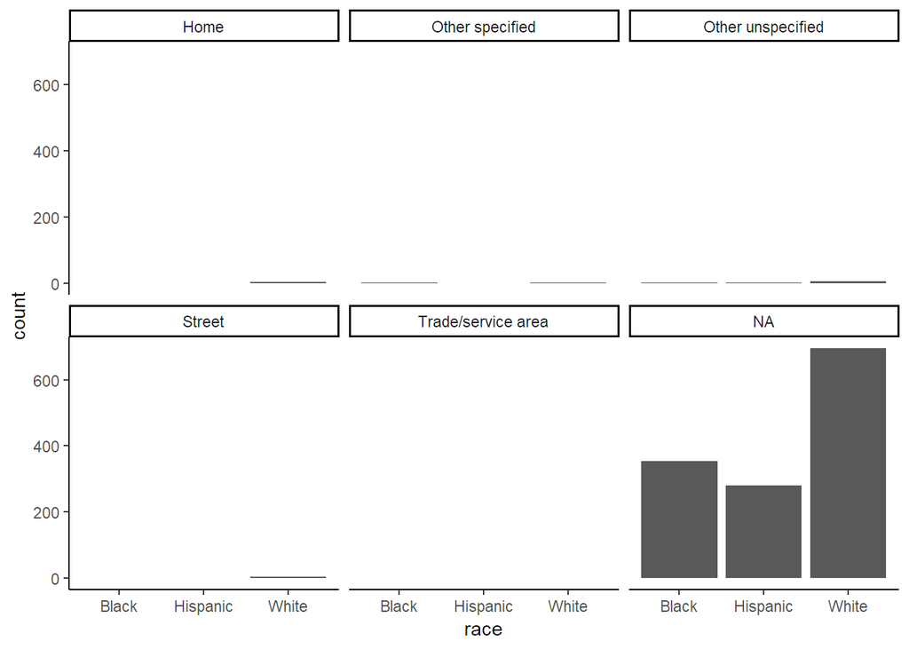

```r
gun_deaths3 %>%
  filter(police == 1 & intent == "Homicide") %>%
  filter(race == "Black" | race == "White" | race == "Hispanic") %>%
  ggplot(aes(x = race)) +
    geom_bar() +
    facet_wrap(~ place)
```

No. Given the coverage in national media, it is stricking to me that police-involved homicides are not greater among African Americans. Then again, these are raw counts, not proportions.

```r
# Police-involved among Whites
(white_homicide <- gun_deaths3 %>%
   filter(race == "White" & intent == "Homicide") %>%
   summarize(
     total = n(),
     proportion = mean(police == 1)
   ))
```

```
## # A tibble: 1 x 2
##   total proportion
##   <int>      <dbl>
## 1  9147     0.0775
```

```r
# Police-involved among Blacks
(black_homicide <- gun_deaths3 %>%
   filter(race == "Black" & intent == "Homicide") %>%
   summarize(
     total = n(),
     proportion = mean(police == 1)
   ))
```

```
## # A tibble: 1 x 2
##   total proportion
##   <int>      <dbl>
## 1 19510     0.0182
```

```r
# Police-involved among Hispanics
(hispanic_homicide <- gun_deaths3 %>%
   filter(race == "Hispanic" & intent == "Homicide") %>%
   summarize(
     total = n(),
     proportion = mean(police == 1)
   ))
```

```
## # A tibble: 1 x 2
##   total proportion
##   <int>      <dbl>
## 1  5634     0.0501
```

Surprisingly, out of all homicides, police involvement was highest among Whites (7.75%) and Hispanics (5.01%). Police-involved homicides occurred in only 1.82% of the cases in which an African American died due to gun violence.

Generally, how often are police involved?

```r
# Number of police involved
(police_involved <- gun_deaths3 %>%
  filter(police == 1) %>%
  count() %>%
  pull())
```

```
## [1] 1402
```

```r
# Proportion of police involved
(prop_police_involved <- police_involved / nrow(gun_deaths3))
```

```
## [1] 0.01390901
```

Between 2012 and 2014, police were only involved in 1402 incidents, or 1.39% of all gun-related deaths.

## Dependencies

This activity was completed in RStudio.

[^1]: For more information on how to create awesome tables, check out Hao Zhu’s [documentation](https://cran.r-project.org/web/packages/kableExtra/vignettes/awesome_table_in_html.html).
[^2]: Start the [origin at zero](https://stackoverflow.com/questions/13701347/force-the-origin-to-start-at-0).